# AHgen - Vignette 4, Visualisation

Dr Annie Visser-Quinn, a.visser-quinn@hw.ac.uk

2020-08-21

This vignette follows on directly from *Vignette 3, Analysis*. You should have the following objects loaded in your environment:

```r
ls()
```

```
##  [1] "adjMat_to_edgelist"              "adjMat_to_igraph"
##  [3] "calcChange"                      "calcEigen"
##  [5] "calcMetrics"                     "calcUWVBC"
##  [7] "calcWVBC"                        "da"
##  [9] "de"                              "de_list"
## [11] "di"                              "dn"
## [13] "dw_edgelist"                     "dw_igraph"
## [15] "dw_weighted"                     "edgelist"
## [17] "edgelist_to_igraph"              "function_igraphResultFormatting"
## [19] "function_mergeNodeInfo"          "internal_add_layerAttribute"
## [21] "internal_edgelist_to_igraph"     "layerKey"
## [23] "melt2"                           "output"
## [25] "read_adjMat_csv"                 "read_adjMat_xlsx"
## [27] "read_indicatorsDatabase"         "read_nodeInfo_csv"
## [29] "read_nodeInfo_xlsx"              "weightLinks"
```

## 1. Box plots

One way to visualise the change signal is boxplots. This example builds on the code used previously, as well as some tips from Information is Beautiful.

First, we need to save the data that we want to work with as an object.

```r
dc <- calcChange(before = calcWVBC(di,dn),
                 after = calcWVBC(dw_weighted, dn),
                 metric = "WVBC")
```

```
## tnet: Analysis of Weighted, Two-mode, and Longitudinal networks.
## Type ?tnet for help.
```

```r
dc
```

```
## # A tibble: 475 x 7
##    layer layerName     nodeName         before after absChange_afterM~ pctChange
##    <dbl> <chr>         <chr>             <dbl> <dbl>             <dbl>     <dbl>
##  1     1 Functional p~ Cultural herita~   19.1    2              -17.1    -89.5
##  2     1 Functional p~ Economic opport~   20.2    0              -20.2   -100
##  3     1 Functional p~ Globalised conn~   48.2    0              -48.2   -100
##  4     1 Functional p~ Knowledge trans~   42.9    0              -42.9   -100
##  5     1 Functional p~ Physical settle~   58.1    0              -58.1   -100
##  6     1 Functional p~ Pooling of reso~   40.9    0              -40.9   -100
##  7     1 Functional p~ Safety and secu~   74.3    2              -72.3    -97.3
##  8     1 Functional p~ Social opportun~   65.4    0              -65.4   -100
##  9     1 Functional p~ Wellbeing         288.     0             -288.    -100
## 10     2 Values and p~ Collective iden~ 1210.  1183.             -27.1     -2.24
## # ... with 465 more rows
```

Next we need to prepare the data into a format for plotting. We need to have the numbers for the boxplot as well as the axis text. `ggplot` has an inbuilt function that will generate the boxplot numbers, but this creates a *Tukey boxplot*. This type of boxplot is often used but it is more heavily focussed on outliers. In this example we produce a boxplot covering the full distribution of values by determining the minimum and maximum values, the interquartile range, and the median.

```r
# Prepare the layers text
dc <- dc %>% mutate(names = paste0(layer, "-", layerName) %>% factor %>% fct_rev)

dc$names %>% unique
```

```
## [1] 1-Functional purposes          2-Values and priority measures
## [3] 3-Generalised functions        4-Object-related processes
## [5] 5-Physical objects
## 5 Levels: 5-Physical objects ... 1-Functional purposes
```

```r
# Prepare the numbers for the box plot
dcSummary <-
  dc %>%
  group_by(names) %>%
  summarise(min = min(pctChange),
            max = max(pctChange),
            lower = quantile(pctChange, 0.25),
            upper = quantile(pctChange, 0.75),
            median = median(pctChange),
            .groups = "drop")

dcSummary
```

```
## # A tibble: 5 x 6
##   names                                min     max     lower    upper    median
##   <fct>                              <dbl>   <dbl>     <dbl>    <dbl>     <dbl>
## 1 5-Physical objects               -0.0412   0.406    0.0565    0.136    0.0967
## 2 4-Object-related processes       -2.98     6.62    -0.0197    0.883    0.378
## 3 3-Generalised functions         -24.7     12.4     -3.05      3.63     1.33
## 4 2-Values and priority measures  -64.6    101.     -44.3      27.7    -16.5
## 5 1-Functional purposes          -100      -89.5   -100      -100     -100
```

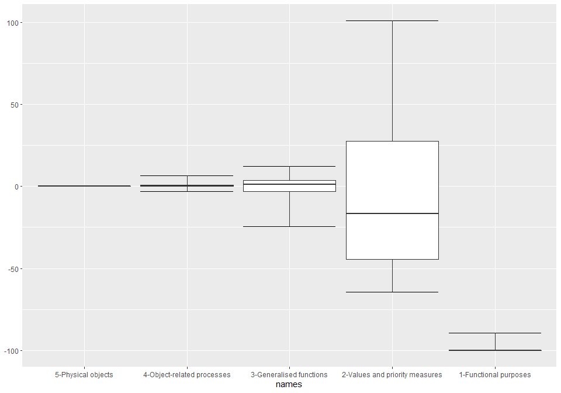

```r
# Prepare the basic plot
dcSummary %>%
  ggplot(aes(x = names, ymin = min, lower = lower, middle = median, upper = upper, ymax = max)) +
  geom_errorbar() +
  geom_boxplot(stat = "identity")
```

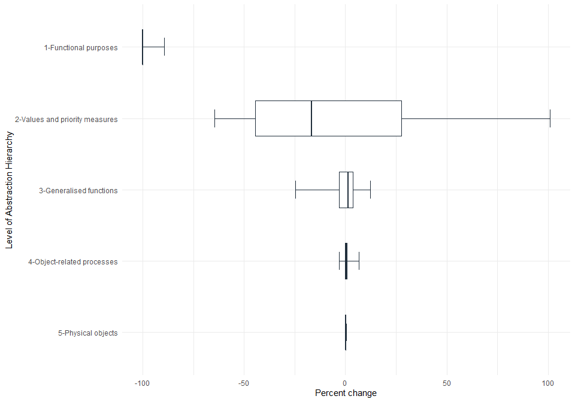

```r
# Add some specifications for visuals
p <-
  dcSummary %>%

  ggplot(aes(x = names, ymin = min, lower = lower, middle = median, upper = upper, ymax = max)) +
  geom_errorbar(width = 0.25, colour = "#212F3C") +
  geom_boxplot(stat = "identity", width = 0.5, colour = "#212F3C") +

  coord_flip() +
  labs(x = "Level of Abstraction Hierarchy", y = "Percent change") +

  theme_minimal(base_size = 11)

p
```

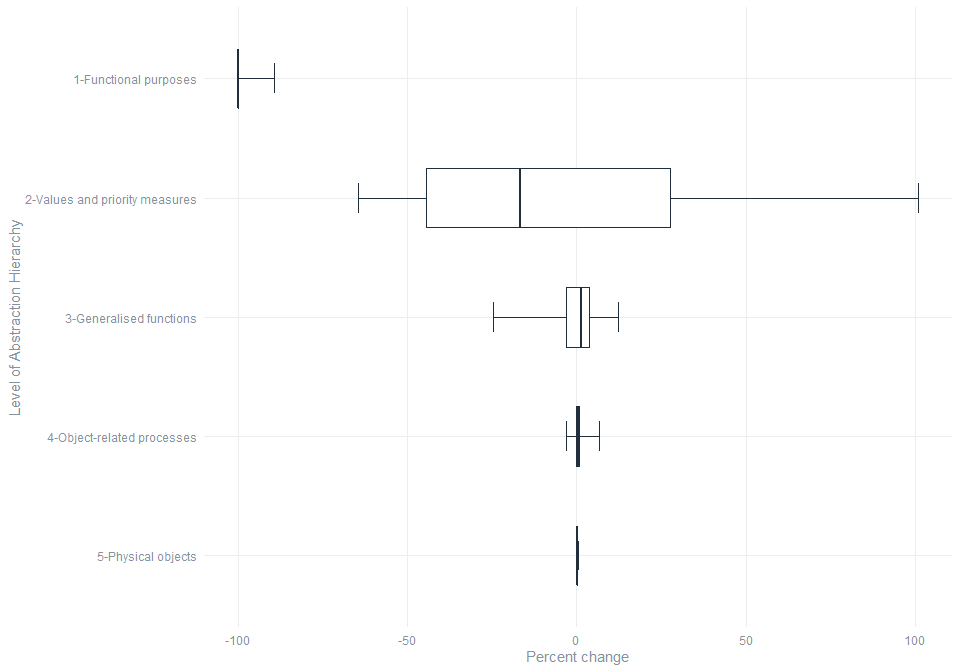

```r
# Once we're happy with the underlying plot we can make a few tweaks using theme.
p <-
  p +
  theme(panel.grid.minor = element_blank(),
        panel.grid = element_line(colour = "#EBEDEF"),
        text = element_text(colour = "#85929E"),
        axis.text = element_text(colour = "#85929E"))

p
```

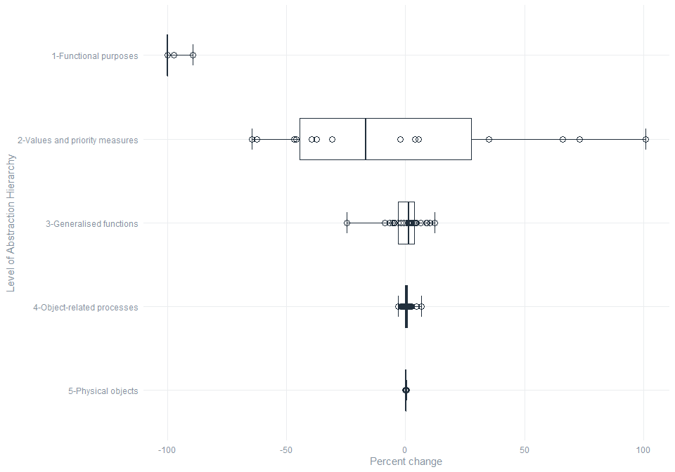

```r
# Overplotting points - why it's not a great idea

# This example is misleading as all the points will bunch up
# It's not clear how many points are located where
p +
  geom_point(data = dc, aes(x = names, y = pctChange), inherit.aes = FALSE,
             colour = "#212F3C", size = 3, shape = 1)
```

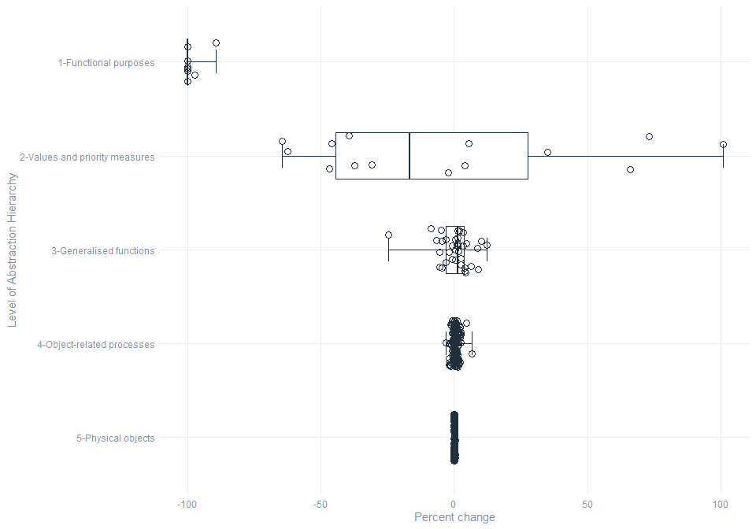

```r
# This version is impossible to read, the points mask the boxplot
p +
  geom_jitter(data = dc, aes(x = names, y = pctChange), inherit.aes = FALSE,
             colour = "#212F3C", size = 3, shape = 1,
             height = 0, width = 0.25)
```

## 2. Ridge plot using ggridges

This example uses the R package `ggridges`. A ridge plot is a series of stacked density (PDF) plots.

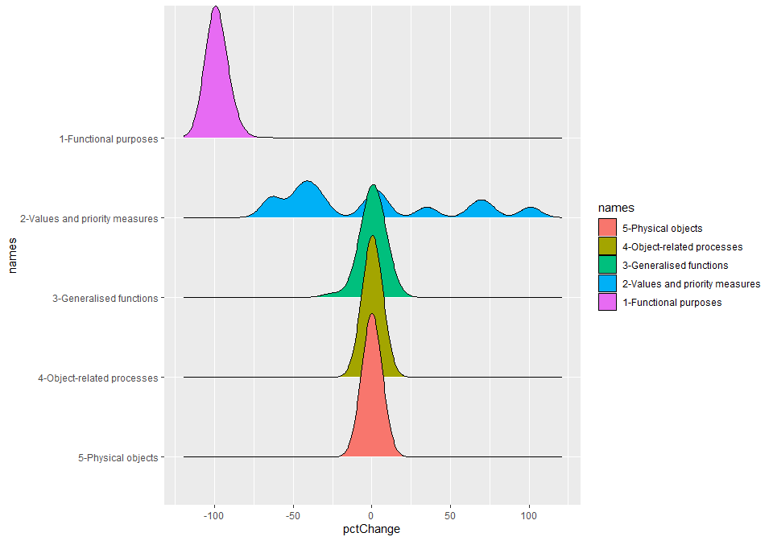

```r
library(ggridges)

dc %>% ggplot(aes(x = pctChange, y = names, fill = names)) + ggridges::geom_density_ridges()
```

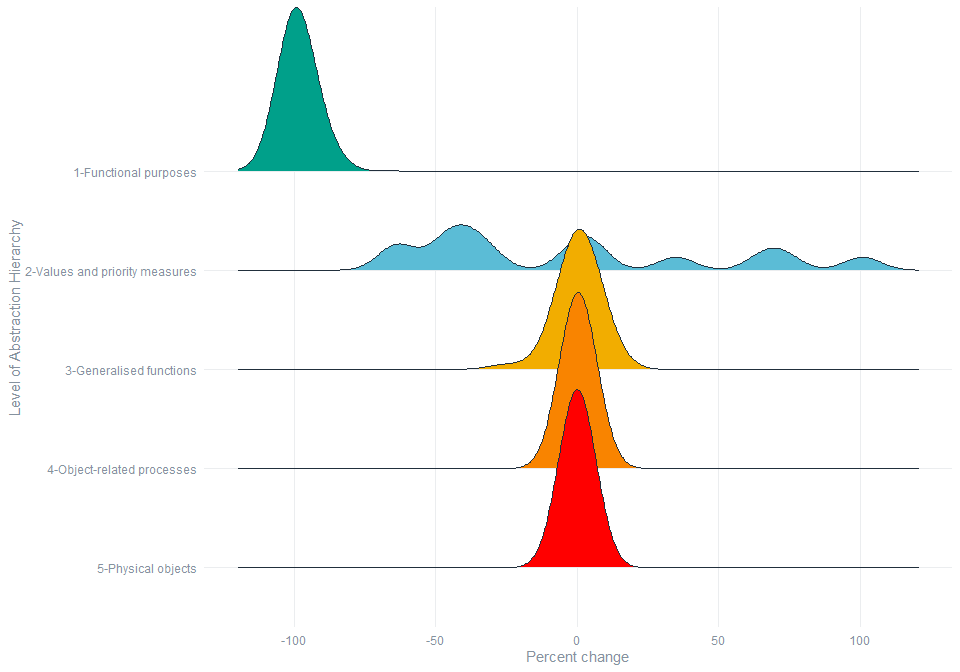

```r
# With formatting
library(wesanderson)

dc %>%
  ggplot(aes(x = pctChange, y = names, fill = names)) +

  ggridges::geom_density_ridges(size = 0.5, colour = "#212F3C") +

  labs(y = "Level of Abstraction Hierarchy", x = "Percent change") +

  theme_minimal(base_size = 11) +
  theme(panel.grid.minor = element_blank(),
        panel.grid = element_line(colour = "#EBEDEF"),
        text = element_text(colour = "#85929E"),
        axis.text = element_text(colour = "#85929E"),
        legend.position = "none") +

  scale_fill_manual(values = wes_palette("Darjeeling1", n = 5)[c(1,4,3,5,2)])
```

## 3. Adjacency matrix plots

```r
# Split the template edge list by layer

de_list <- de %>% mutate(from = fct_inorder(from), to = fct_inorder(to)) %>% split(., .$layers)
de_list
```

```
## $l1FP_l2VPM
## # A tibble: 62 x 4
##    layers    from                         to                              weight
##    <chr>     <fct>                        <fct>                            <dbl>
##  1 l1FP_l2V~ Cultural heritage and sense~ Collective identity and commun~      1
##  2 l1FP_l2V~ Cultural heritage and sense~ Environmental sustainability         1
##  3 l1FP_l2V~ Cultural heritage and sense~ Integrated development and pla~      1
##  4 l1FP_l2V~ Cultural heritage and sense~ Socio-economic equality and eq~      1
##  5 l1FP_l2V~ Economic opportunity         Diverse livelihoods and employ~      1
##  6 l1FP_l2V~ Economic opportunity         Reliable communications and mo~      1
##  7 l1FP_l2V~ Economic opportunity         Socio-economic equality and eq~      1
##  8 l1FP_l2V~ Economic opportunity         Sustainable economy                  1
##  9 l1FP_l2V~ Globalised connectivity      Diverse livelihoods and employ~      1
## 10 l1FP_l2V~ Globalised connectivity      Effective leadership and manag~      1
## # ... with 52 more rows
##
## $l2VPM_l3GF
## # A tibble: 141 x 4
##    layers    from                         to                              weight
##    <chr>     <fct>                        <fct>                            <dbl>
##  1 l2VPM_l3~ Collective identity and com~ Ceremonies and services for ma~      1
##  2 l2VPM_l3~ Collective identity and com~ Communication systems                1
##  3 l2VPM_l3~ Collective identity and com~ Community activities and engag~      1
##  4 l2VPM_l3~ Collective identity and com~ Foster social cohesion               1
##  5 l2VPM_l3~ Collective identity and com~ Historical and cultural value ~      1
##  6 l2VPM_l3~ Collective identity and com~ Learning and education               1
##  7 l2VPM_l3~ Collective identity and com~ Observance of religion               1
##  8 l2VPM_l3~ Collective identity and com~ Recreational activities              1
##  9 l2VPM_l3~ Collective identity and com~ Social interaction                   1
## 10 l2VPM_l3~ Collective identity and com~ Societal hazard regulation           1
## # ... with 131 more rows
##
## $l3GF_l4ORP
## # A tibble: 694 x 4
##    layers     from           to                                 weight
##    <chr>      <fct>          <fct>                               <dbl>
##  1 l3GF_l4ORP Animal welfare Administrate retail activity            1
##  2 l3GF_l4ORP Animal welfare Animal rescue                           1
##  3 l3GF_l4ORP Animal welfare Criminal investigation                  1
##  4 l3GF_l4ORP Animal welfare Enforce environmental standards         1
```

[output cut: 8 more lines]

```
## $l4ORP_l5PO
## # A tibble: 3,223 x 4
##    layers     from                              to                        weight
##    <chr>      <fct>                             <fct>                      <dbl>
##  1 l4ORP_l5PO Accommodates prisoners            Prison and jails               1
##  2 l4ORP_l5PO Act as access point for electric~ Accountancy firms              1
##  3 l4ORP_l5PO Act as access point for electric~ Advertising                    1
##  4 l4ORP_l5PO Act as access point for electric~ Agriculture and aquacult~      1
##  5 l4ORP_l5PO Act as access point for electric~ Air bases                      1
##  6 l4ORP_l5PO Act as access point for electric~ Airports (major)               1
##  7 l4ORP_l5PO Act as access point for electric~ Airports (minor)               1
##  8 l4ORP_l5PO Act as access point for electric~ Ambulance stations             1
##  9 l4ORP_l5PO Act as access point for electric~ Animal care                    1
## 10 l4ORP_l5PO Act as access point for electric~ Animal shelters                1
## # ... with 3,213 more rows
```

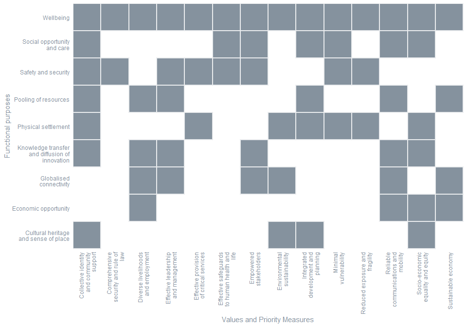

```r
p1 <-
  de_list$l1FP_l2VPM %>%
  rename(y = from, x = to) %>%

ggplot(aes(x = str_wrap(x, width = 20),
           y = str_wrap(y, width = 20))) +

geom_tile(fill = "#85929E", colour = "#EBEDEF", size = 1) +

scale_x_discrete(expand = c(0,0)) +
scale_y_discrete(expand = c(0,0)) +

  theme_minimal(base_size = 11) +
  theme(panel.grid.minor = element_blank(),
        panel.grid = element_blank(),
        text = element_text(colour = "#85929E"),
        axis.text.y = element_text(colour = "#85929E"),
        axis.text.x = element_text(colour = "#85929E", angle = 90, hjust = 1, vjust = 0.5),
        axis.ticks = element_blank()) +

  labs(x = "Values and Priority Measures", y = "Functional purposes")

p1
```

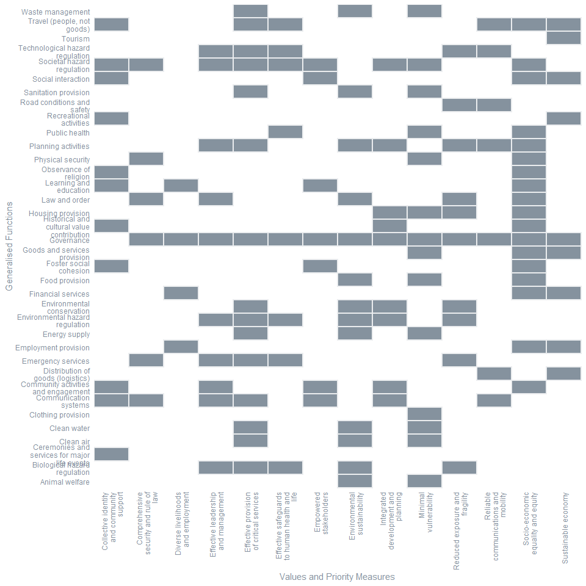

```r
# We can reuse this plot using `%+%` and changing the labels

p2 <- p1 %+% (de_list$l2VPM_l3GF %>% rename(x = from, y = to)) + labs(y = "Generalised Functions")
p2
```

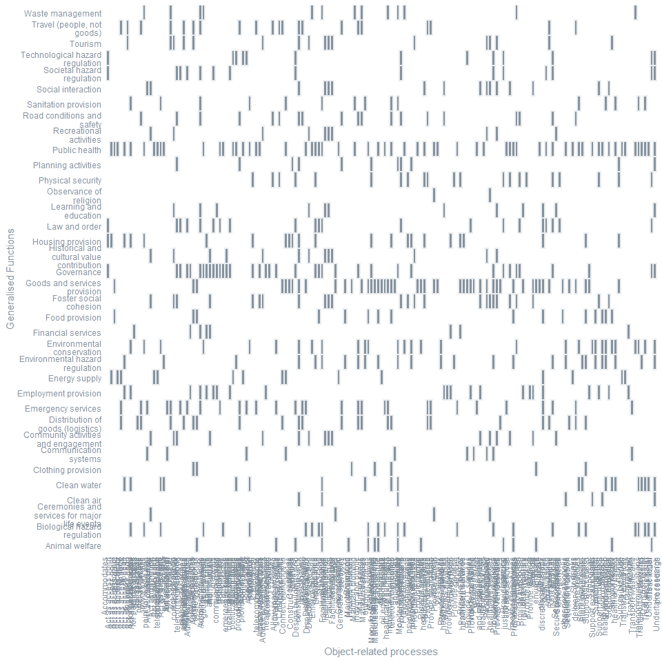

```r
# Repeat for the third level - becomes hard to read at this point
p3 <- p2 %+% (de_list$l3GF_l4ORP %>% rename(x = to, y = from)) + labs(x = "Object-related processes")
p3
```

An alternative way to do the adjacency matrix plot is to remove more visual features and make the plot interactive using the package `plotly`.

```r
# Use the same level of the AH, but add some weightings to try to make the visualisation more meaningful.
dt3 <-
  de_list$l3GF_l4ORP %>%
  rename(x = to, y = from) %>%
  mutate(weight = sample(seq(0,1,0.001), n()),
         Link = paste0("from ", y, " to ", x))

dt3
```

```
## # A tibble: 694 x 5
##    layers   y          x                   weight Link
##    <chr>    <fct>      <fct>                <dbl> <chr>
##  1 l3GF_l4~ Animal we~ Administrate retai~  0.587 from Animal welfare to Admini~
##  2 l3GF_l4~ Animal we~ Animal rescue        0.731 from Animal welfare to Animal~
##  3 l3GF_l4~ Animal we~ Criminal investiga~  0.796 from Animal welfare to Crimin~
##  4 l3GF_l4~ Animal we~ Enforce environmen~  0.561 from Animal welfare to Enforc~
##  5 l3GF_l4~ Animal we~ Houses animals       0.726 from Animal welfare to Houses~
##  6 l3GF_l4~ Animal we~ Manage pests         0.53  from Animal welfare to Manage~
##  7 l3GF_l4~ Animal we~ Manufacture consum~  0.687 from Animal welfare to Manufa~
##  8 l3GF_l4~ Animal we~ Manufacture consum~  0.506 from Animal welfare to Manufa~
##  9 l3GF_l4~ Animal we~ Monitor environment  0.607 from Animal welfare to Monito~
## 10 l3GF_l4~ Animal we~ Provide animal hea~  0.086 from Animal welfare to Provid~
## # ... with 684 more rows
```

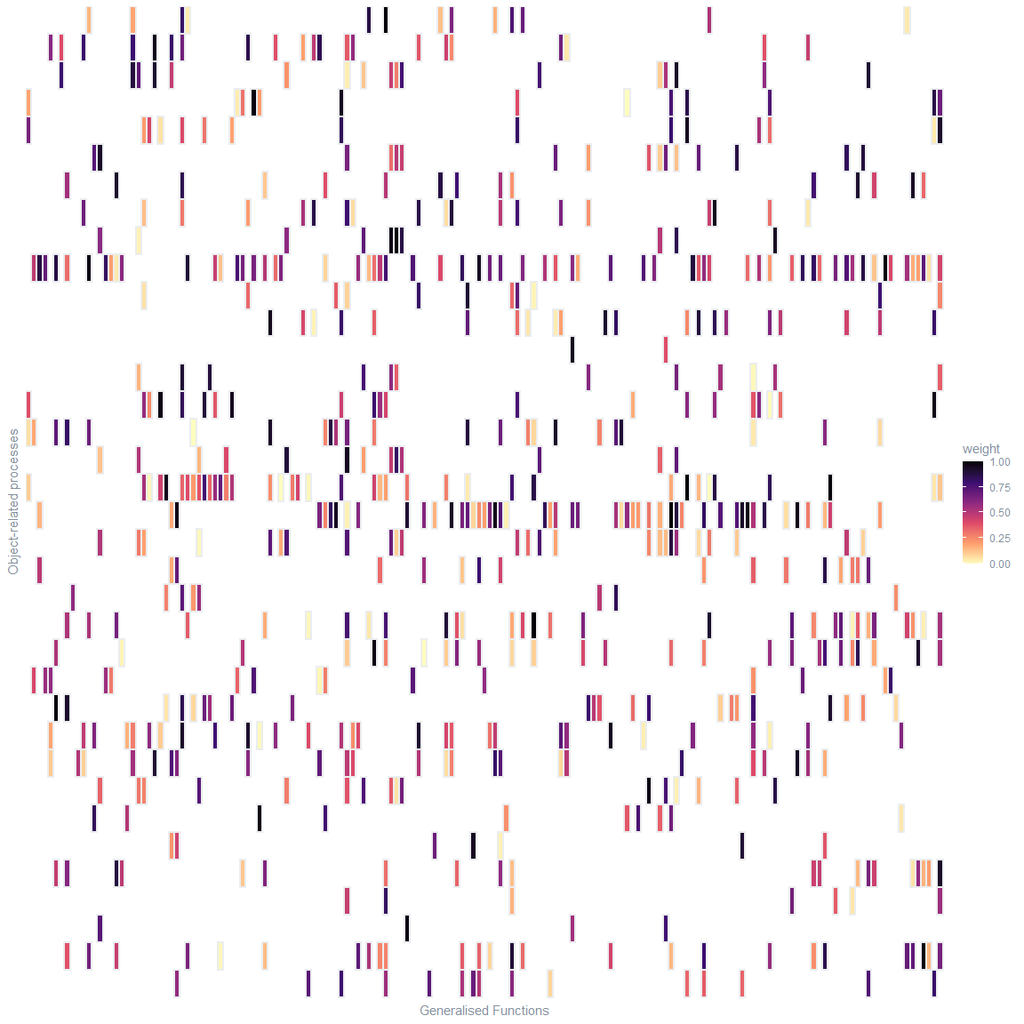

```r
p4 <-
  dt3 %>%

  ggplot(aes(x = str_wrap(x, width = 20),
           y = str_wrap(y, width = 20),
           label = Link)) +

  geom_tile(aes(fill = weight), colour = "#EBEDEF", size = 1) +

  scale_x_discrete(expand = c(0,0)) +
  scale_y_discrete(expand = c(0,0)) +
  scale_fill_viridis_c(option = "A", direction = -1) +

  theme_minimal(base_size = 11) +
  theme(panel.grid.minor = element_blank(),
        panel.grid = element_blank(),
        text = element_text(colour = "#85929E"),
        axis.text = element_blank(),
        axis.ticks = element_blank()) +

  labs(x = "Generalised Functions", y = "Object-related processes")
p4
```

```r
library(plotly)
ggplotly(p4, tooltip = "label")
```

[interactive chart not shown]

Not included, but can be discussed, time allowing:

- Other types of matrix plot
- Fabric
- Focus network plots

Omitted from this version of AHgen:

- Using geospatial data
- Cutting out (flood) hazards
- Sensitvitiy